# R Notebook

# Load Libraries

```r
library(tidyverse)
library(GGally)
library(modelr)
library(ggfortify)
```

# Load / Explore Data

```r
housing_prices <- read_csv(here::here("data/housing_prices.csv"))
dim(housing_prices)
```

```
[1] 19675    10
```

```r
glimpse(housing_prices)
```

```
Rows: 19,675
Columns: 10
$ longitude          <dbl> -122.23, -122.22, -122.24, -122.25, -122.25, -122.25, -122.25, -122.25…
$ latitude           <dbl> 37.88, 37.86, 37.85, 37.85, 37.85, 37.85, 37.84, 37.84, 37.84, 37.84, …
$ housing_median_age <dbl> 41, 21, 52, 52, 52, 52, 52, 52, 42, 52, 52, 52, 52, 52, 52, 50, 52, 52…
$ total_rooms        <dbl> 880, 7099, 1467, 1274, 1627, 919, 2535, 3104, 2555, 3549, 2202, 3503, …
$ total_bedrooms     <dbl> 129, 1106, 190, 235, 280, 213, 489, 687, 665, 707, 434, 752, 474, 191,…
$ population         <dbl> 322, 2401, 496, 558, 565, 413, 1094, 1157, 1206, 1551, 910, 1504, 1098…
$ households         <dbl> 126, 1138, 177, 219, 259, 193, 514, 647, 595, 714, 402, 734, 468, 174,…
$ median_income      <dbl> 8.3252, 8.3014, 7.2574, 5.6431, 3.8462, 4.0368, 3.6591, 3.1200, 2.0804…
$ median_house_value <dbl> 452600, 358500, 352100, 341300, 342200, 269700, 299200, 241400, 226700…
$ ocean_proximity    <chr> "NEAR BAY", "NEAR BAY", "NEAR BAY", "NEAR BAY", "NEAR BAY", "NEAR BAY"…
```

# We expect the total_rooms of houses to be strongly correlated with total_bedrooms. Use ggpairs() to investigate correlations between these two variables.

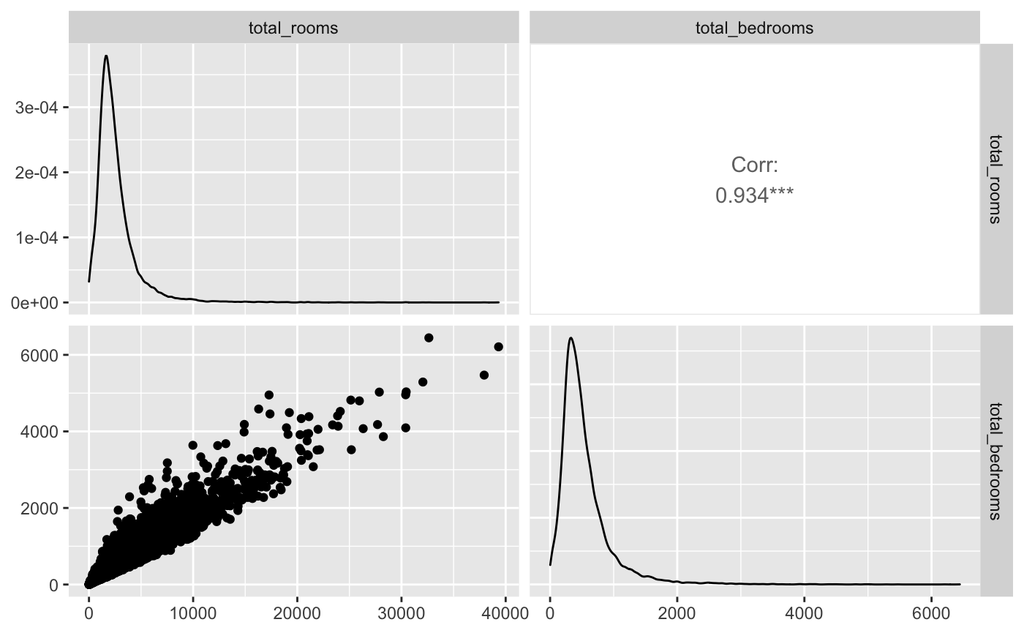

```r
housing_prices %>%
  select(total_rooms, total_bedrooms) %>%
  ggpairs()
```

**Interpretation**

The correlation coefficient comes out to 0.934, which corresponds to a very strong positive correlation. As you increase total rooms, total bedrooms also increases.

# So, we do find significant correlations. Let’s drop total_bedrooms from the dataset, and use only total_rooms going forward.

```r
# remove total_bedrooms
housing_prices <- housing_prices %>%
  select(-total_bedrooms)
```

# We are interested in developing a regression model for the median_house_value of a house in terms of the possible predictor variables in the dataset.

Use ggpairs() to investigate correlations between median_house_value and the predictors (this may take a while to run, don’t worry, make coffee or something).

[output not shown]

[output cut: 34 more lines]

[output not shown]

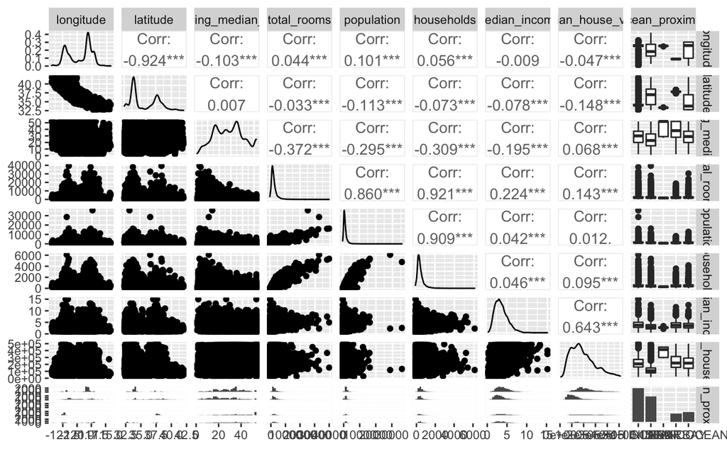

```r
housing_prices %>%
  ggpairs()
```

Perform further ggplot visualisations of any significant correlations you find.

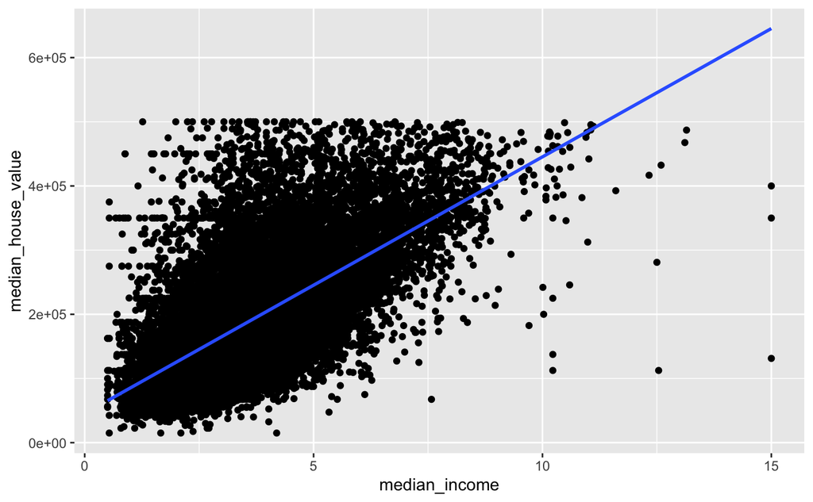

```r
# plot of median_house_value ~ median_income
housing_prices %>%
  ggplot(aes(x = median_income, y = median_house_value)) +
  geom_point() +
  geom_smooth(method = "lm", se = F)
```

```r
NA
```

# Shortly we may try a regression model to fit the categorical predictor ocean_proximity. Investigate the level of ocean_proximity predictors. How many dummy variables do you expect to get from it?

```r
housing_prices %>%
  distinct(ocean_proximity)
```

| ocean_proximity |
| --- |
| NEAR BAY |
| <1H OCEAN |
| INLAND |
| NEAR OCEAN |
| ISLAND |

**Interpretation**

Since there are 5 total levels of ocean_proximity, I would expect to have 4 dummy variables after one has been used as a reference.

# Start with simple linear regression. Regress median_house_value on median_income and check the regression diagnostics.

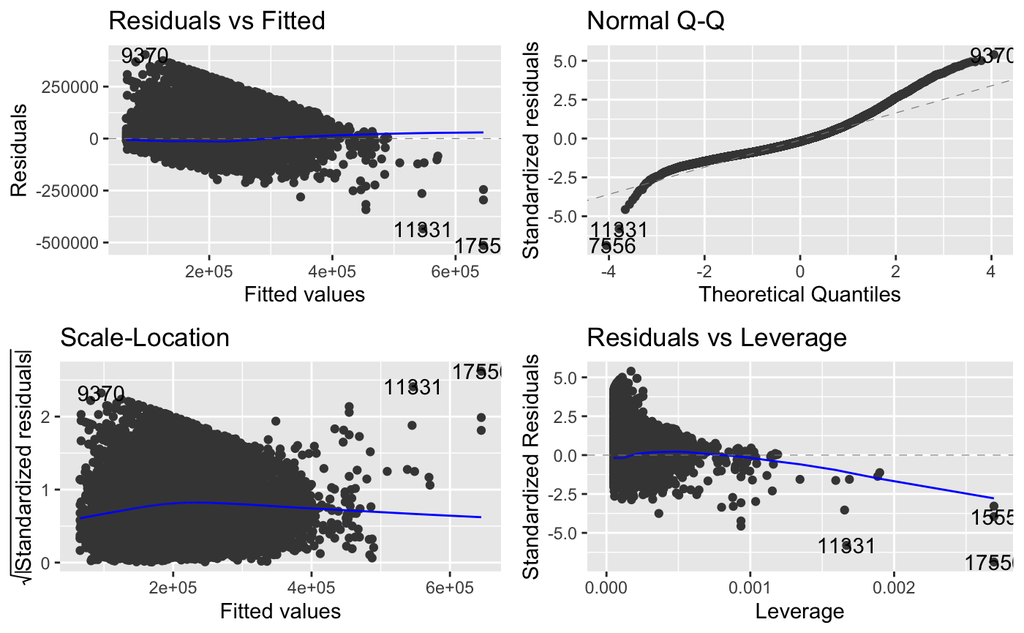

```r
model <- lm(median_house_value ~ median_income, data = housing_prices)

autoplot(model)
```

```r
summary(model)
```

```
Call:
lm(formula = median_house_value ~ median_income, data = housing_prices)

Residuals:
    Min      1Q  Median      3Q     Max
-513966  -51564  -13979   36549  403935

Coefficients:
              Estimate Std. Error t value Pr(>|t|)
(Intercept)    45457.0     1359.0   33.45   <2e-16 ***
median_income  39987.0      339.9  117.64   <2e-16 ***
---
Signif. codes:  0 ‘***’ 0.001 ‘**’ 0.01 ‘*’ 0.05 ‘.’ 0.1 ‘ ’ 1

Residual standard error: 74870 on 19673 degrees of freedom
Multiple R-squared:  0.4129,    Adjusted R-squared:  0.4129
F-statistic: 1.384e+04 on 1 and 19673 DF,  p-value: < 2.2e-16
```

**Interpretation**

*Residuals v Fitted* The residuals form a steady horizontal line around 0, which suggests the variances of errors are roughly equal. However, the residuals don’t quite bounce randomly around the zero line which suggests the linear relationship may not fit this data well.

*Normal QQ Plot* The points appears to wrap around the normal line loosely, I’d have concerns here and suggest that the test of normality isn’t passed. The data is potentially skewed.

*Scale-Location* There is a funnel effect that has formed, with the data going from wider to narrower for greater fitted values. This indicates that there isn’t a constancy of variance in our residuals.

*Adjusted R-Squared* Our value comes to 0.4129. This tells us that 41.3% of the variance in our dependent variable (median_house_value) is explained by our independent variable (median_income). This gives a reasonable fit, however, with the earlier diagnostics shows that we can most likely do better.

*Residual Standard Error* this is a large value of 74870, again, this speaks to the variance of errors we witnessed in our diagnostic plots.

# Add another predictor of your choice. Check your assumptions, diagnostics, and interpret the model.

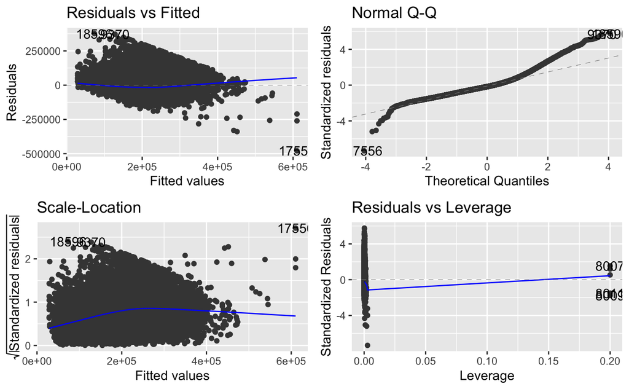

```r
model2 <- lm(median_house_value ~ median_income + ocean_proximity, data = housing_prices)

autoplot(model2)
```

```r
summary(model2)
```

```
Call:
lm(formula = median_house_value ~ median_income + ocean_proximity,
    data = housing_prices)

Residuals:
    Min      1Q  Median      3Q     Max
-479055  -41086  -11143   27912  376647

Coefficients:
                          Estimate Std. Error t value Pr(>|t|)
(Intercept)                83581.2     1407.7  59.373  < 2e-16 ***
median_income              35118.0      304.8 115.223  < 2e-16 ***
ocean_proximityINLAND     -72313.7     1100.7 -65.695  < 2e-16 ***
ocean_proximityISLAND     200480.2    29232.9   6.858 7.19e-12 ***
ocean_proximityNEAR BAY    16629.7     1591.9  10.446  < 2e-16 ***
ocean_proximityNEAR OCEAN  15552.9     1500.8  10.363  < 2e-16 ***
---
Signif. codes:  0 ‘***’ 0.001 ‘**’ 0.01 ‘*’ 0.05 ‘.’ 0.1 ‘ ’ 1

Residual standard error: 65340 on 19669 degrees of freedom
Multiple R-squared:  0.5529,    Adjusted R-squared:  0.5528
F-statistic:  4865 on 5 and 19669 DF,  p-value: < 2.2e-16
```

**Interpretation**

*Residuals vs Fitted* Again, the line is fairly horizontal around zero, however the residuals don’t randomly bounce around the zero line which leads me to believe that it doesn’t quite fit this linear relationship well.

*Normal QQ Plot* It is quite similar to before, it loosely falls on the normal line the middle part of our data, however, it is not close to that thereafter. There may be some concerns with the normality of our residuals.

*Scale-Location* There is a similar funnel effect for lower fitted values, but the line does keep fairly horizontal. There may still be some concern for the constancy of variance in our residuals.

*Adjusted R Squared* Our value has increased to 0.5528, a slightly better fit, however, we would expect an increase with the addition of any predictor. This now means that 55.3% of the variation in our response variable is explained by the predictor variables.

*Residuals Standard Error* This has decreased to 65340, an improvement on the previous model and a slightly better fit, however, it is still large.

# Extension

Try adding an interaction between log(medium_income) and your chosen categorical predictor. Do you think this interaction term is statistically justified?

```r
# add interaction between log(median_income) and ocean_proximity
model3 <- lm(median_house_value ~ median_income + log(median_income):ocean_proximity,
             data = housing_prices)
```

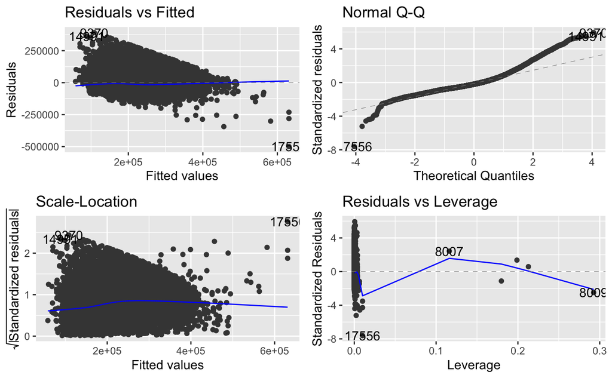

```r
# diagnostic plots for model3
autoplot(model3)
```

```r
#summary of model3
summary(model3)
```

```
Call:
lm(formula = median_house_value ~ median_income + log(median_income):ocean_proximity,
    data = housing_prices)

Residuals:
    Min      1Q  Median      3Q     Max
-499788  -41738  -12925   27822  391556

Coefficients:
                                             Estimate Std. Error t value Pr(>|t|)
(Intercept)                                     60174       1458  41.280  < 2e-16 ***
median_income                                   35474       1034  34.304  < 2e-16 ***
log(median_income):ocean_proximity<1H OCEAN     14325       3703   3.869  0.00011 ***
log(median_income):ocean_proximityINLAND       -41887       3685 -11.368  < 2e-16 ***
log(median_income):ocean_proximityISLAND       210999      29443   7.166 7.98e-13 ***
log(median_income):ocean_proximityNEAR BAY      28372       3803   7.460 8.98e-14 ***
log(median_income):ocean_proximityNEAR OCEAN    31010       3762   8.244  < 2e-16 ***
---
Signif. codes:  0 ‘***’ 0.001 ‘**’ 0.01 ‘*’ 0.05 ‘.’ 0.1 ‘ ’ 1

Residual standard error: 65990 on 19668 degrees of freedom
Multiple R-squared:  0.5441,    Adjusted R-squared:  0.5439
F-statistic:  3912 on 6 and 19668 DF,  p-value: < 2.2e-16
```

**Interpretation**

I don’t believe this interaction term is statistically justified, based on the diagnostic plots and adjusted R Squared value.

In the Scale-Location plot the residuals appear to have a greater ‘funnel’ effect. The residuals for lower fitted values appear much more spread than greater fitted values. The model appears to be a poor fit in terms of constancy of variation among residuals. It has not improved the model fit in terms of the other plots either.